# CAPRO user survey

among internal LCBC staff & externa collaborators

Author

Dr. Athanasia M. Mowinckel

## Summary

On February 01, 2023 the survey “*User survey LCBC - colllaborators*” was launched to investigate the interest in an online tools that would help researchers in Norway run experimental behavioural data collection online in a Norwegian legal framework. As of February 10, 2023 the survey has collected 18 responses from 2 main sources (LCBC and Lifebrain).

## Background

At LCBC, there is a set of core staff that deal with processing and structuring of data and analyses. Markus, Inge and Mo work full-time in securing safe workflows and making sure data can be used for staff. In addition we have a dedicated person for MRI general processing, the last years this has been Jamila and Fredrik.

This set of staff is working on an application that deals with their working conditions and would like to have feedback from those who have worked with them about how the work they do impacts your own work.

## Survey results

Of the 18 responses to the survey, the majority of responders (72%) were from lcbc. Full presentation of main work place and field of study can be found in Figure 1. The survey relied on snow-ball sampling to reach researchers that would be interested in the tool suggested, and as such has likely not reached all potential interested.

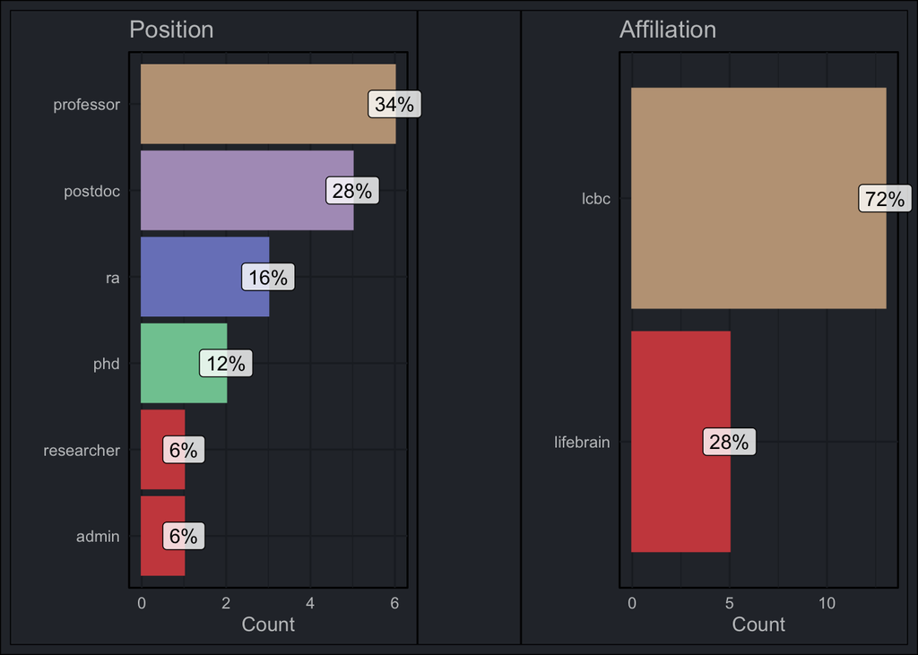

Figure 1: The position titles and affiliations for the survey responders.

```r
ggbar(dt, position) +
  plot_spacer() +
  ggbar(dt, affiliation) +
  plot_layout(widths = c(1, .3, 1))
```

In general, respondents are satisfied with the help they receive from the team in question. As seen in Figure 2, they score high in perceived level of help from the staff they aid, as well as in level of comfort approaching them for help. Some free-text comments mention that some solutions provided still have a high technical skill requirement to master, and that the availability of the team members is a times very pressed as they have many tasks to fulfil. This gives us a clear idea of what we can work on to improve, and also the need for more staff in order to properly fill all the required assistance that is needed.

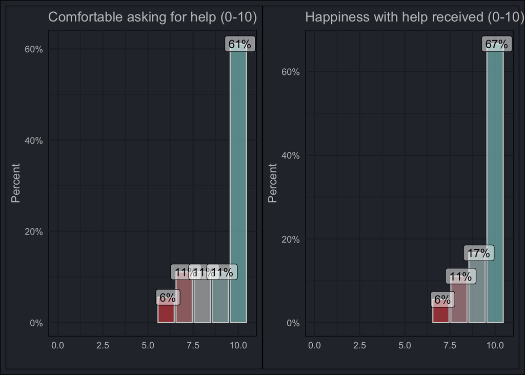

Figure 2: Ratings of satisfaction and levels of comfort when asking for help.

```r
p1 <- dt |>
  group_by(comfortable) |>
  tally() |>
  mutate(
    pc = n/sum(n)
  ) |>
  ggplot(aes(comfortable, pc)) +
  geom_bar(stat = "identity",
           aes(fill = comfortable),
           alpha = .7,
           color = "grey82",
           show.legend = FALSE) +
  geom_label(aes(label = scales::percent(pc, accuracy = 1)),
             nudge_x = .1,
             alpha = .5) +
  labs(title = "") +
  scale_x_continuous(limits = c(0, 10.5)) +
  scale_y_continuous(labels = scales::percent) +
  labs(y = "Percent",
       title = "Comfortable asking for help (0-10)",
       x = "")

p2 <- dt |>
  group_by(help) |>
  tally() |>
  mutate(
    pc = n/sum(n)
  ) |>
  ggplot(aes(help, pc)) +
  geom_bar(stat = "identity", aes(fill = help),
           alpha = .7,
           color = "grey82",
           show.legend = FALSE) +
  geom_label(aes(label = scales::percent(pc, accuracy = 1)),
             nudge_x = .1,
             alpha = .5) +
  labs(title = "") +
  scale_x_continuous(limits = c(0, 10.5)) +
  scale_y_continuous(labels = scales::percent) +
  labs(y = "Percent",
       title = "Happiness with help received (0-10)",
       x = "")

p1 + p2
```

Indeed, in the three free-text boxes provided, many comments encompass the benefit of having the availability of the team, and that the need for more staff doing similar tasks would clearly aid others in doing their work.

> *“It can’t be overstated how critical the work of the technical staff is to LCBC. In particular, database management, preprocessing pipelines and their development, development of useful tools that improve research workflows, both for researchers in-house, and the neuroimaging community across the world (e.g. developing packages like "ggseg"). We all benefit immensely from their work.”* Survey responder nr. 5

# Conclusion

In general, the staff is helpful and approachable by the staff at LCBC and collaborators in Lifebrain. The help they provide is very satisfactory, and the main critical points are that there is need for more of this type of help and that there is room for improvement in making tools that are even more accessible.